# SML201 Chapter 2.4

# Examples

## A simple example

Suppose that we would like to use a side-by-side boxplot to compare the age distributions of the passengers by ticket class.

```r
class(t.ship)
[1] "data.frame"
# the dataset `t.ship` is already in data.frame format

ggplot(t.ship) + geom_boxplot(mapping = aes(x = as.factor(Pclass),
    y = Age, fill = as.factor(Pclass))) + labs(y = "Titanic Passenger Ages (Years)",
    x = "Ticket Classes", title = "Titanic Passenger Age Distributions by Ticket Class",
    fill = "Ticket Class")
```

[output not shown]

Notice that the argument `fill = as.factor(Pclass)` was placed inside of the `aes()` function. If we use a particular color for `fill` the argument should be placed outside of the `aes()` function.

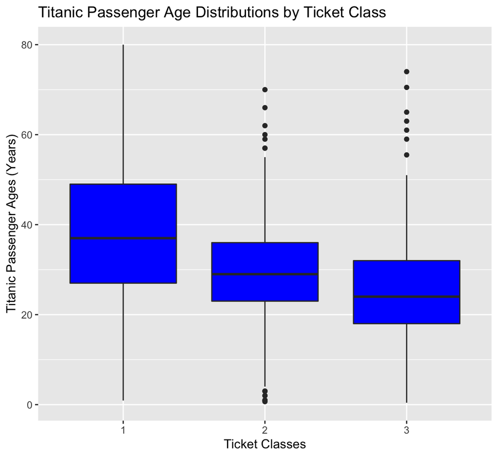

```r
ggplot(t.ship) + geom_boxplot(mapping = aes(x = as.factor(Pclass),
    y = Age), fill = "blue") + labs(y = "Titanic Passenger Ages (Years)",
    x = "Ticket Classes", title = "Titanic Passenger Age Distributions by Ticket Class",
    fill = "Ticket Class")
```

Also, notice that you can also place the mapping argument in the `ggplot()` function. Can you think of a situation where it will be good to do this?

```r
ggplot(t.ship, mapping = aes(x = as.factor(Pclass), y = Age,
    fill = as.factor(Pclass))) + geom_boxplot() + labs(y = "Titanic Passenger Ages (Years)",
    x = "Ticket Classes", title = "Titanic Passenger Age Distributions by Ticket Class",
    fill = "Ticket Class")
```

[output not shown]

## A more complex graph

Eventually we will make the graph shown at the beginning of the chapter but let’s start with something simpler first.

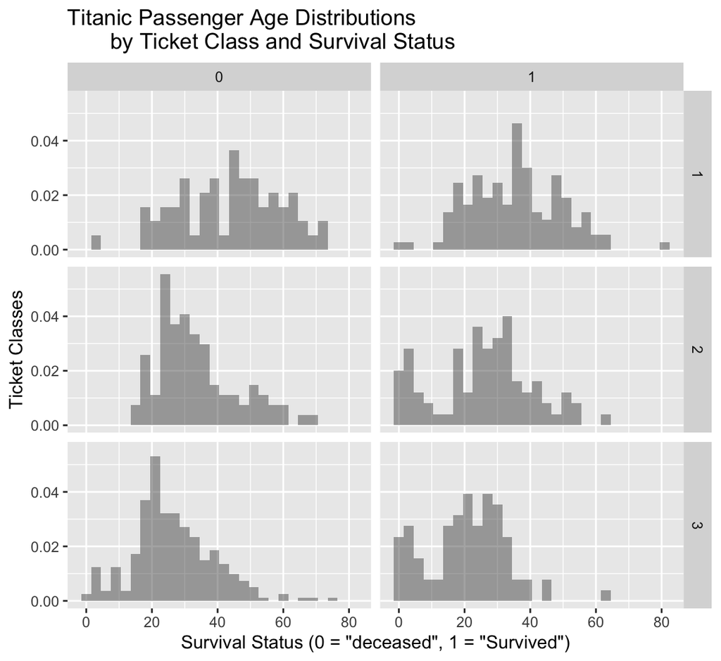

```r
ggplot(t.ship) + # `..density..` allows me to use density for the y-axis
# `binwidth` sets the bin width `alpha` sets the transparency
# of the graph
geom_histogram(mapping = aes(x = Age, y = ..density..), binwidth = 3,
    alpha = 0.5) + # `facet_grid` allows me to make a different plot for each
# subset of the data note that the variable on either side of
# `~` has to be a factor
facet_grid(as.factor(Pclass) ~ as.factor(Survived)) + # this tells R to create panels for the unique combinations
# of the `Pclass` values and the `Survived` values: the
# `Pclass` values correspond to the rows and the `Survived`
# value correspond to the columns
labs(x = "Survival Status (0 = \"deceased\", 1 = \"Survived\")",
    y = "Ticket Classes", title = "Titanic Passenger Age Distributions
       by Ticket Class and Survival Status")
```

Now, let’s produce the graph shown at the beginning of the chapter!

Exercise 1.: Produce a set of histograms for the passenger ages by ticket classes (rows) and gender (columns).

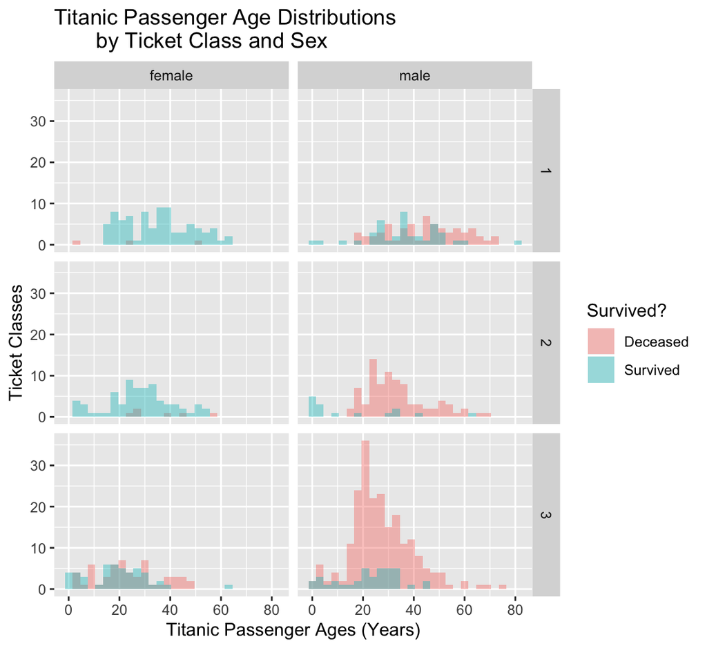

```r
ggplot(t.ship) + # ggplot(t.ship) tells R that you're using
                 # the data in `t.ship` to make the graph
   geom_histogram(mapping = aes(x = Age,
                                fill = as.factor(Survived)),
                  # features related to the data in the
                  # dataset should be included in
                  # mapping = aes().
                  # fill = as.factor(Survived) gives different color to
                  # the graph for different the values in `Survived`
                  position="identity",
                  # the default is position="stack" which
                  # stacks the bins
                  binwidth = 3, alpha = .4) +
                  # alpha controls the transparency of the bins
  facet_grid(as.factor(Pclass)~Sex) +
  # this tells R to create panels for the unique combinations of
  # the `Pclass` values and the `Sex` values:
  # the `Pclass` values correspond to the rows and
  # the `Sex` value correspond to the columns
  labs(x='Titanic Passenger Ages (Years)',
       y='Ticket Classes',
       title = 'Titanic Passenger Age Distributions
       by Ticket Class and Sex',
       fill = "Survived?" ) +
       # fill = "Survived?" is the header for the legend
  scale_fill_discrete(labels = c("Deceased", "Survived"))
```

```r
  # this labels the categories in the legend

# Warning message:
# Removed 177 rows containing non-finite values (stat_bin).
# This Warning is due to the fact that there are 177 missing
# values in `Age`
```

### How to read the plots

In the set of the histograms above the area of a bin (relative to the total area of all the bins) represents the proportion of the passengers in a particular category relative to *all the Titanic passengers*. This is because R plots the absolute counts in the set of the histograms above. You can check this with the data:

```r
with(t.ship, table(Pclass[Survived == 0], Sex[Survived == 0]))

    female male
  1      3   77
  2      6   91
  3     72  300
# this is the equivalent to
# table(t.ship$Pclass[t.ship$Survived == 0], t.ship$Sex[t.ship$Survived == 0]).
# the `with()` function allows you to tell R that all the data that you
# are using are from the dataset `t.ship`.
```

```r
with(t.ship, table(Pclass[Survived == 1], Sex[Survived == 1]))

    female male
  1     91   45
  2     70   17
  3     72   47
```

Note that if we add in the `y = ..density..` argument the graph will give a different interpretation of the data:

In this case the area of a bin represents the proportion of the passengers in a particular category relative to all the passengers that fall on *a particular grid with a particular color*.

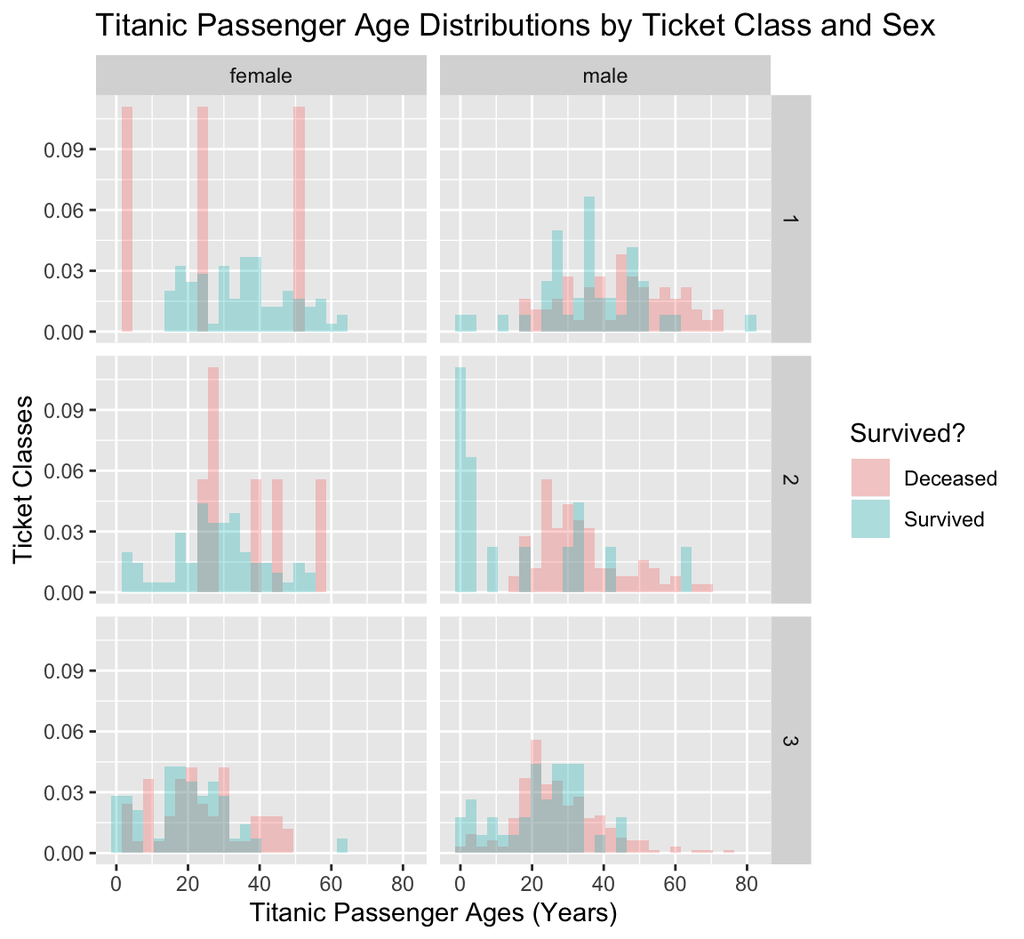

```r
ggplot(t.ship) +
   geom_histogram(mapping = aes(x = Age, y = ..density..,
                                fill = as.factor(Survived)),
                  position="identity", binwidth = 3,
                  alpha = .3) +
  facet_grid(as.factor(Pclass)~Sex) +
  labs(x='Titanic Passenger Ages (Years)',
       y='Ticket Classes',
       title = 'Titanic Passenger Age Distributions by Ticket Class and Sex',
       fill = "Survived?" ) +
 scale_fill_discrete(labels = c("Deceased", "Survived"))
```

## `ggpairs()`: investigating the overall pairwise relationship between variables.

We will first extract out the variables that we need for the graph.

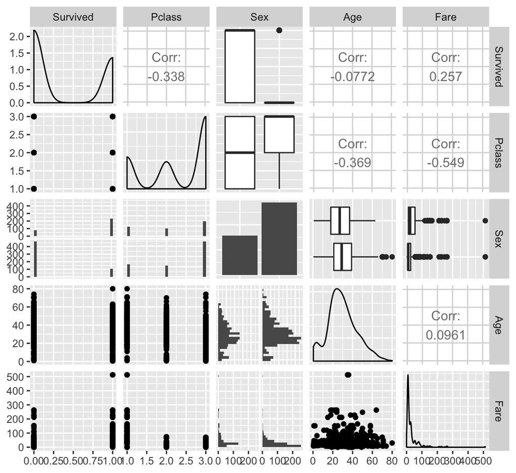

```r
library(GGally)
# you will always need the `ggplot2` package when you are
# using the `GGally` package so make sure that you already
# load the `ggplot2` package too
small.t.ship = t.ship[, c("Survived", "Pclass", "Sex", "Age",
    "Fare")]
ggpairs(small.t.ship)
```

This is called a matrix plot.

Some of the graphs on the matrix plot don’t look right because they are not in the correct data types.

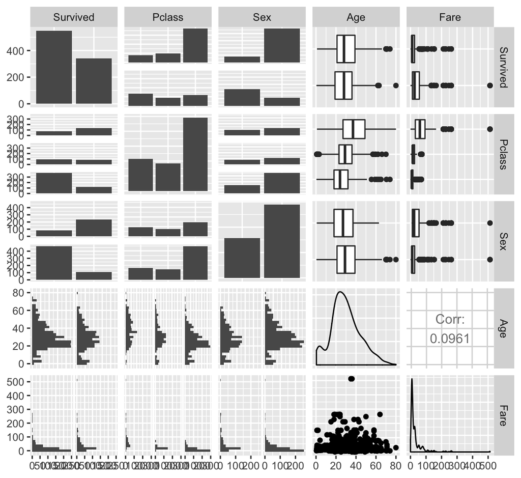

```r
str(small.t.ship)
'data.frame':   891 obs. of  5 variables:
 $ Survived: int  0 1 1 1 0 0 0 0 1 1 ...
 $ Pclass  : int  3 1 3 1 3 3 1 3 3 2 ...
 $ Sex     : Factor w/ 2 levels "female","male": 2 1 1 1 2 2 2 2 1 1 ...
 $ Age     : num  22 38 26 35 35 NA 54 2 27 14 ...
 $ Fare    : num  7.25 71.28 7.92 53.1 8.05 ...

# change the categorical variables to factors
small.t.ship$Survived = as.factor(t.ship$Survived)
small.t.ship$Pclass = as.factor(t.ship$Pclass)

ggpairs(small.t.ship)
```

Now, we can also compare the pairwise relationship of the variables within each of the survived and deceased groups.

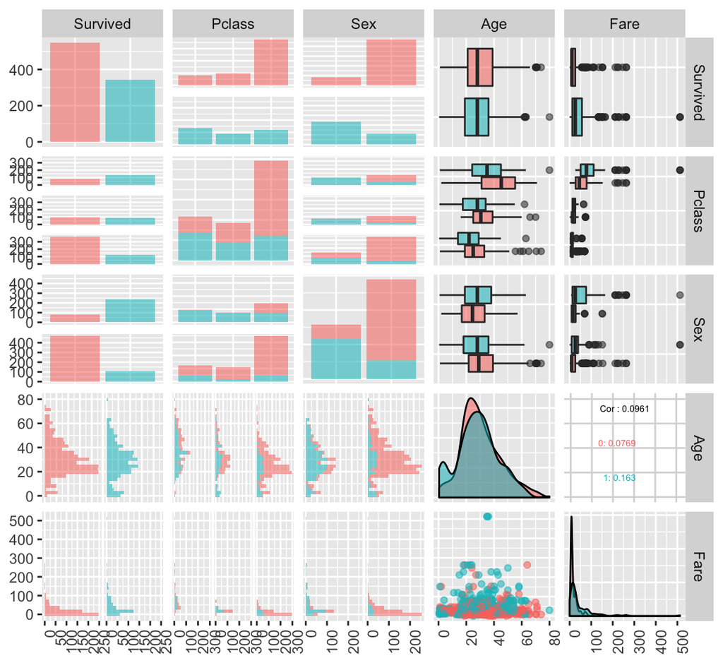

```r
ggpairs(small.t.ship, aes(colour = Survived, alpha = 0.4), upper = list(continuous = wrap("cor",
    size = 1.9))) + theme(axis.text.x = element_text(angle = 90,
    hjust = 1))
```